# Auto-detection of non-solar light

Bindoff, A.

22 September 2018

## Non-solar light

The TwilightFree method of geolocation (Bindoff et al 2017) estimates global locations from ambient light records but, due to a key assumption of the method, fails wherever non-solar light appears at an intensity above the intensity observed during crepuscular light. The `thresholdPlot` plotting function that is packaged with the `TwilightFree` R package helps to identify non-solar light, which can be removed using the `eraseLight` function. This is a two-step manual process - plot the light record, then manually draw a box around non-solar light to “erase” it. This quickly becomes laborious for more than a few tracks, and one of the key selling points of the `TwilightFree` package is that fitting tracks requires minimal (subjective) user input. A further, and perhaps more serious complication, is that users tended to set thresholds much higher than necessary in order to avoid bright moonlight, leading to sub-optimal estimation of locations. In a recent large-scale double-tagging experiment (GLS and GPS tags on the same animal) it was noted that the most difficult to correct source of location error was choice of a suitable zenith and threshold, for which locations estimates are highly sensitive.

In response to a need for auto-detection of non-solar light sources at scale, we present a fast, replicable method for estimating thresholds without confounding with non-solar light, and for removal of non-solar light once a threshold has been determined.

Data from a double-tagging study of a northern elephant seal will serve as an example. Ambient light was recorded using a time-depth recorder. Elephant seals dive deeply and frequently, leading to a substantial attenuation of light to the sensor.

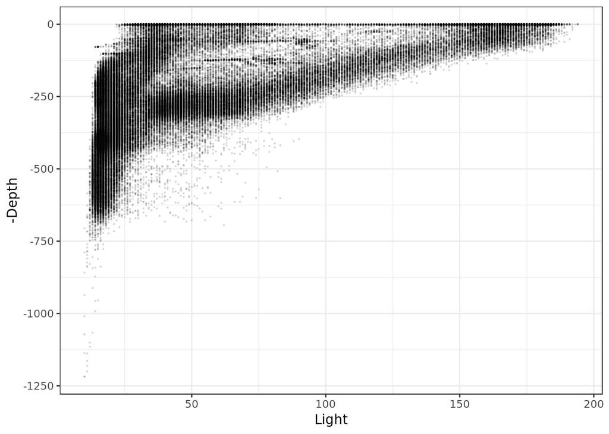

### Smoothing step

The first step filters observations below a threshold depth and re-samples to a more coarse sampling frequency, taking the maximum observed light in each period. This removes some of the “noise” caused by diving. A simple moving average is applied to the Light data as a further smoothing step.

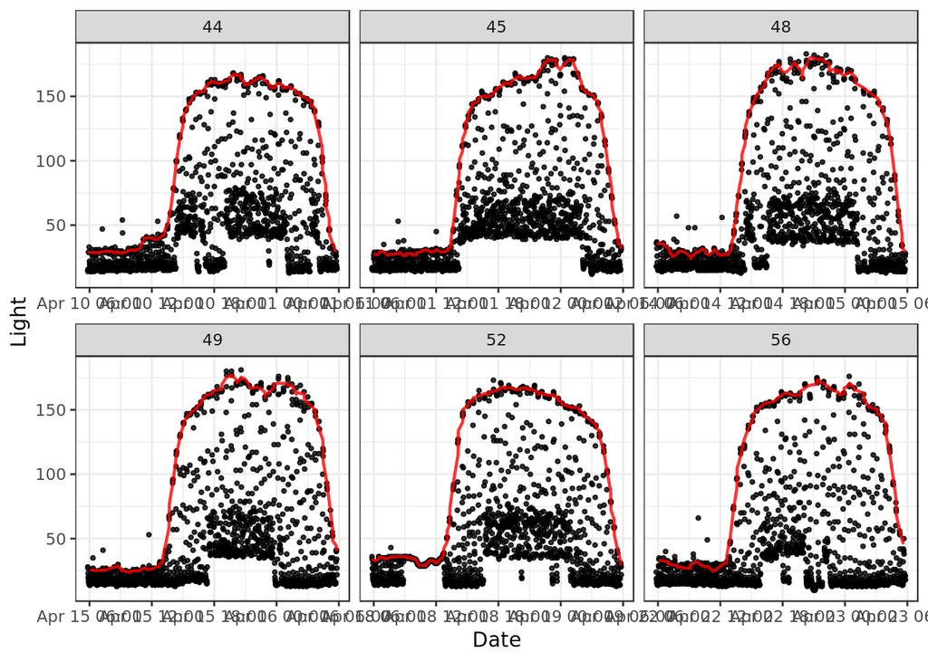

The rate of change in light ($\Delta_{light}$) is then calculated, with an additional smoothing step (also a simple moving average). A latent class multivariate-normal mixture model is then used to classify day, twilight, and night phases from the distributions of light and $\Delta_{light}$. The class with the lowest median light is classified as “night” and the remaining two classes collapsed into a single “day” class.

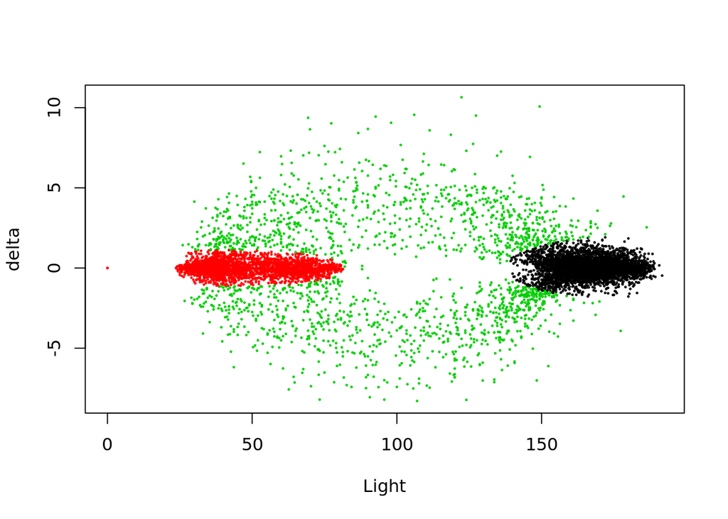

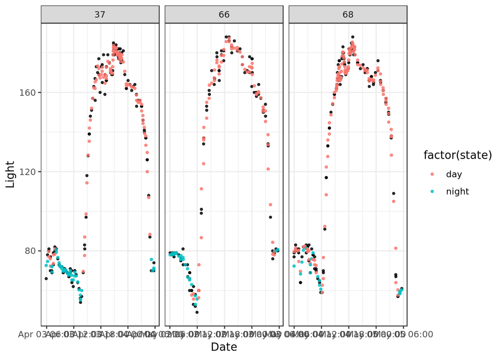

A threshold is determined by observing the maximum light in “night” classes. A small margin for error is added to the threshold to allow for misclassified observations.

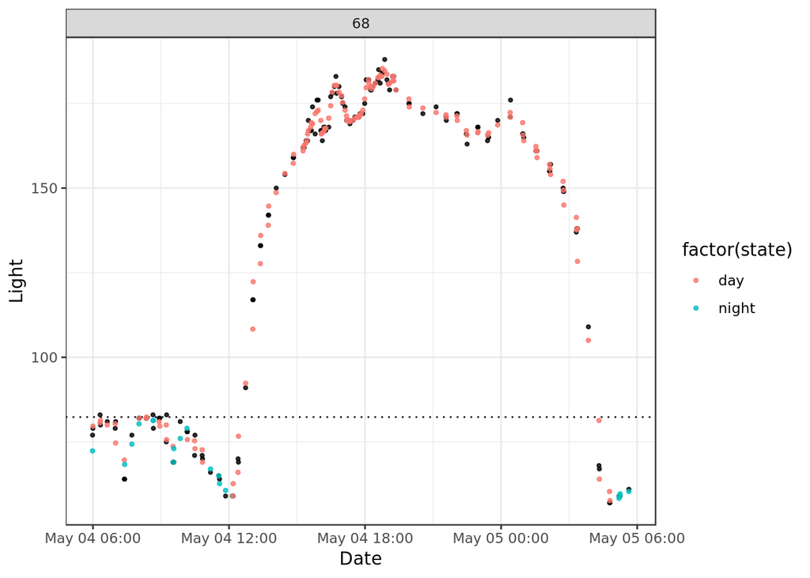

Misclassified observations may have a higher light intensity than threshold, and indeed, often do as this `thresholdPlot()` shows. This was a particularly bright moonlit night, as the original light data show.

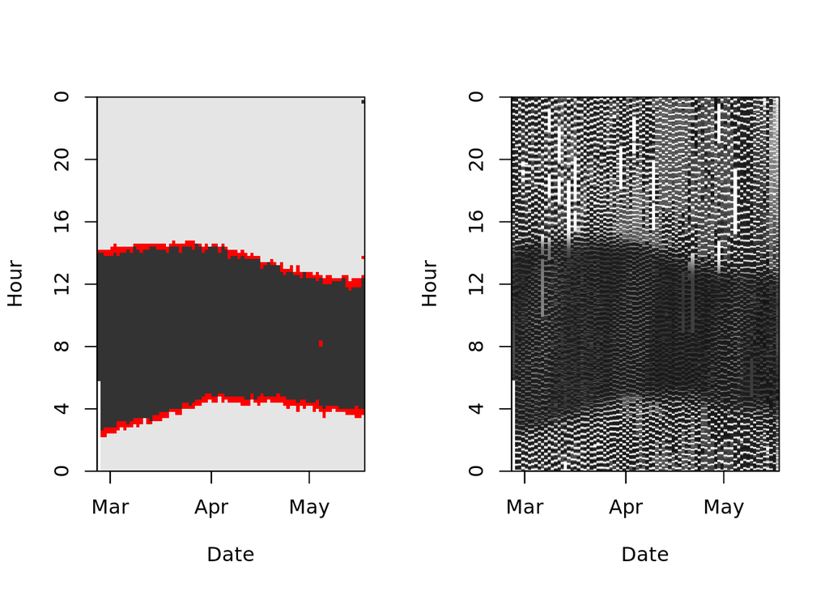

### SVM step

The previous step provides labels for a support vector machine (SVM) to learn from. We can train the SVM quickly using data that has a low likelihood of bright moonlight. The `find_moon()` function simply calculates quantiles and arranges days in order of the brightness of the the bottom quantile. `erase_moon()` finds a suitable training set and conditions on Light and time of day, then updates classifications on all data. `erase_moon()` will optionally return the SVM so that it can be used on new data without need for the the previous steps, potentially useful in high-throughput work-flows, with the caveat that this is not well tested and is quite likely to make errors in inverse proportion to the similarity between the new data and the old data.

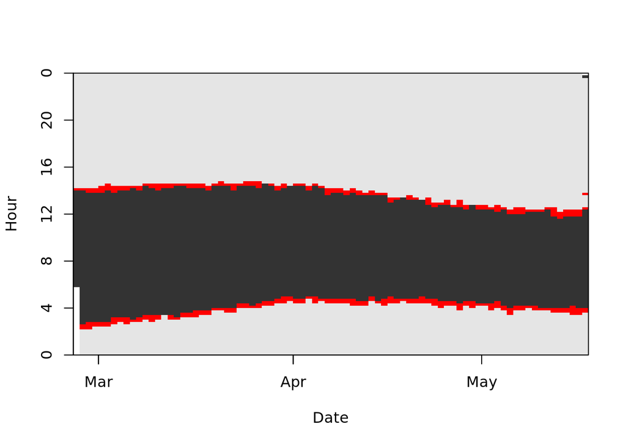

In fact, we can use the trained model on the unsmoothed raw data, and get a reasonably good first-pass.

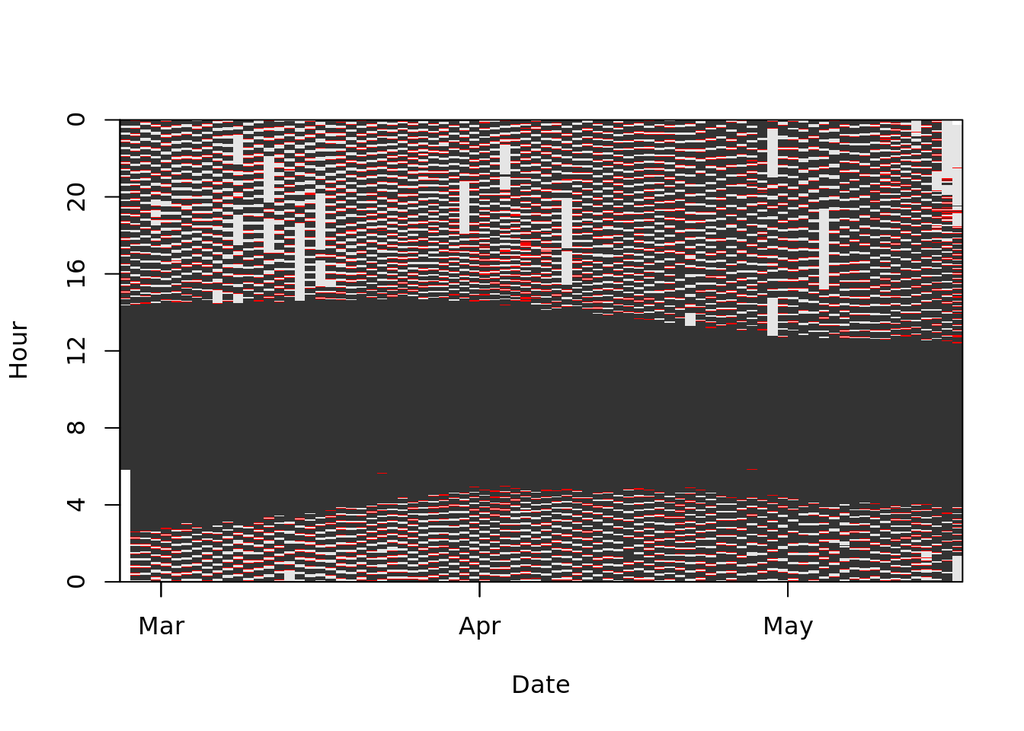

Just for fun, we can train a new model from this data and … this is how computers eventually become self-aware so we’ll stop there.

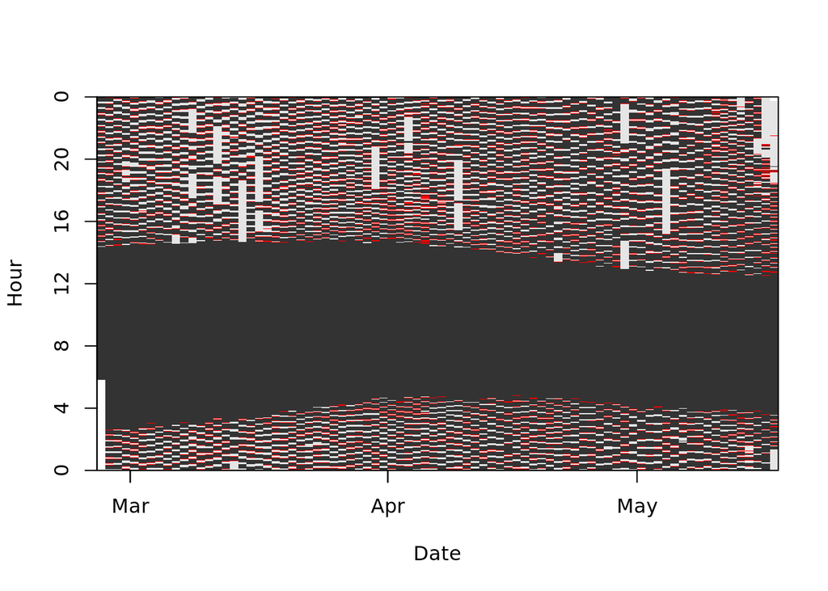

### Zenith angle

`findZenith()` takes a threshold and light data at known location-times and simulates zenith angles returning the minimum zenith where the observed light during simulated nights for those locations does not exceed the thresold. The “optimum” zenith is chosen as percentile of the vector of thresholds. *(I don’t know which one is the optimum, but it’s somewhere in here!)*

```r
z <- sapply(seq(from = (min(b$Day_num)), to = (max(b$Day_num))), function(x) findZenith(b,
          d.sat$Date[d.sat$Day_num == x][1], d.sat$Lon[d.sat$Day_num == x][1],
          d.sat$Lat[d.sat$Day_num == x][1], threshold = max.threshold))
plot(z)
abline(h = quantile(z, 0.1))
```

[output not shown]

```r
quantile(z, 0.5)
```

[output not shown]